# Suite of tests from thigh phantom

W. Bauer

October 24, 2015

This note documents construction of a test suite of pixelated images based on a phantom thigh section. The suite does not involve misalignment or noise. It involves rectangular sections at a total of 8 positions and orientations, each digitized at resolutions (pixel sizes) corresponding to transducer arrays of 16, 32, 64, and 128 elements.

The first task was to identify rectangular sections. This was a trial and error process, performed off-line. Resulting sections are shown below in various colors. All are 30 mm in height, which is approximately that of a 128 element ultrasound probe.

[figure not shown]

Controlling an image’s height in pixels is a bit tricky. The following checks a calculation to do so.

```
##      scan target_height actual_height grid_size_mm
## 1  scan_1           128           128    0.2300036
## 2  scan_1            64            64    0.4636800
## 3  scan_1            32            32    0.9425033
## 4  scan_1            16            16    1.9494994
## 5  scan_2           128           128    0.2300036
## 6  scan_2            64            64    0.4636800
## 7  scan_2            32            32    0.9425033
## 8  scan_2            16            16    1.9494994
## 9  scan_3           128           128    0.2300036
## 10 scan_3            64            64    0.4636800
## 11 scan_3            32            32    0.9425033
## 12 scan_3            16            16    1.9494994
## 13 scan_4           128           128    0.2300036
## 14 scan_4            64            64    0.4636800
```

[output cut: 18 more lines]

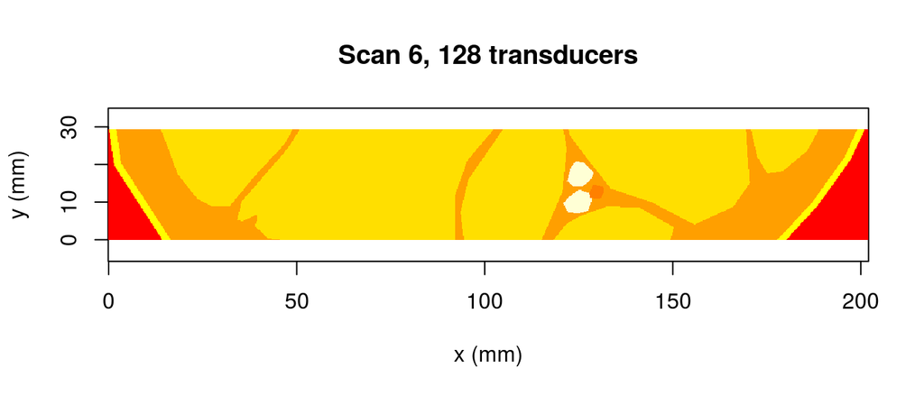

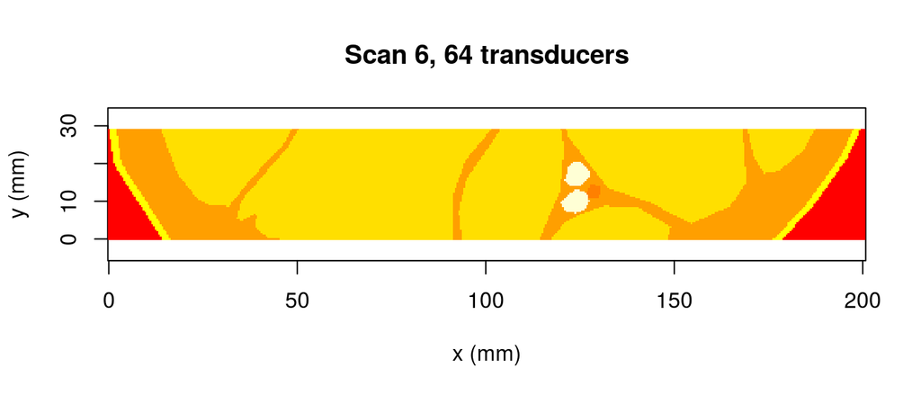

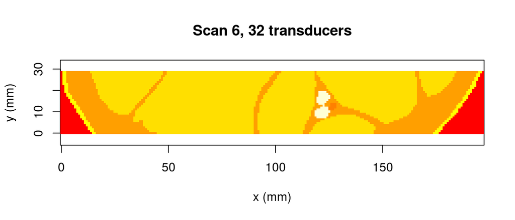

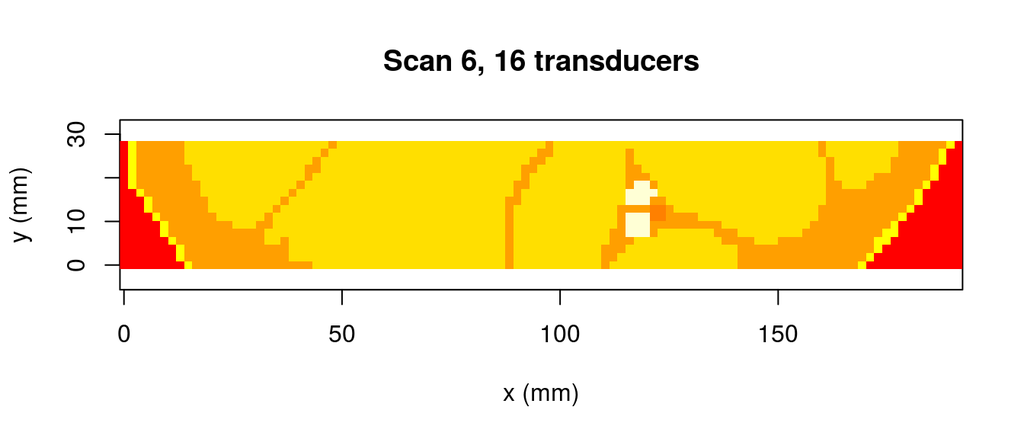

File `thigh_script.R` contains two utilities whose use is illustrated below.

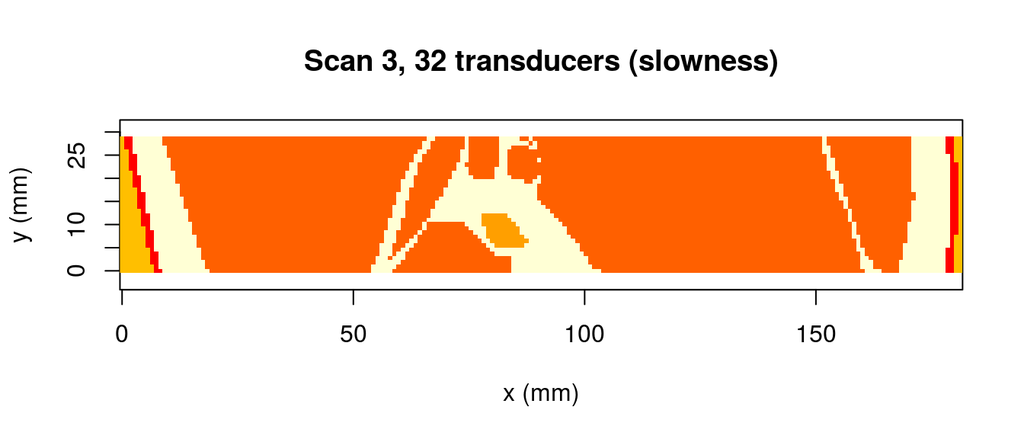

```r
# Read scan 3, resolution 32
img <- readScan(3, 32, datadir="../data")
# Convert tissue identifiers to slowness values
img <- tissue2Slowness(img, datadir = "../data")
# display the result
image(x = 4*.23 * seq(0, nrow(img)-1),
        y = 4* .23 * seq(0, ncol(img)-1),
        z = img, xlab="x (mm)", ylab="y (mm)",
        main = paste0("Scan 3, ", 32, " transducers (slowness)"), asp=1)
```